# M6 Data Analysis: Two Sample Means

Benjamin Panny

11/2/2021

```
## Loading objects:
##   data
```

# 1 Change in Severity Score

What is the average change in headache severity score between baseline and 1 year?

## 1.1 Numerical and Visual Summary

```r
kableExtra::kable(summarize(data, pk1_nNA = sum(is.na(pk1)), mean = mean(pk1, na.rm = TRUE), SD = sd(pk1,
    na.rm = TRUE), median = median(pk1, na.rm = TRUE), IQR = quantile(pk1, 0.75, na.rm = TRUE) - quantile(pk1,
    0.25, na.rm = TRUE), min = min(pk1, na.rm = TRUE), max = max(pk1, na.rm = TRUE)), digits = 3, "simple",
    caption = "Numerical Summary of Headache Severity Scores at Baseline")
```

Numerical Summary of Headache Severity Scores at Baseline

| pk1_nNA | mean | SD | median | IQR | min | max |
| --- | --- | --- | --- | --- | --- | --- |
| 0 | 26.51 | 16.163 | 21 | 19.25 | 6.75 | 94.75 |

```r
kableExtra::kable(summarize(data, pk2_nNA = sum(is.na(pk2)), mean = mean(pk2, na.rm = TRUE), SD = sd(pk2,
    na.rm = TRUE), median = median(pk2, na.rm = TRUE), IQR = quantile(pk2, 0.75, na.rm = TRUE) - quantile(pk2,
    0.25, na.rm = TRUE), min = min(pk2, na.rm = TRUE), max = max(pk2, na.rm = TRUE)), digits = 3, "simple",
    caption = "Numerical Summary of Headache Severity Scores at 3-month Follow-up")
```

Numerical Summary of Headache Severity Scores at 3-month Follow-up

| pk2_nNA | mean | SD | median | IQR | min | max |
| --- | --- | --- | --- | --- | --- | --- |
| 75 | 21.598 | 16.785 | 16.875 | 16.25 | 0 | 98.5 |

```r
kableExtra::kable(summarize(data, pk5_nNA = sum(is.na(pk5)), mean = mean(pk5, na.rm = TRUE), SD = sd(pk5,
    na.rm = TRUE), median = median(pk5, na.rm = TRUE), IQR = quantile(pk5, 0.75, na.rm = TRUE) - quantile(pk5,
    0.25, na.rm = TRUE), min = min(pk5, na.rm = TRUE), max = max(pk5, na.rm = TRUE)), digits = 3, "simple",
    caption = "Numerical Summary of Headache Severity Scores at 1-year Follow-up")
```

Numerical Summary of Headache Severity Scores at 1-year Follow-up

| pk5_nNA | mean | SD | median | IQR | min | max |
| --- | --- | --- | --- | --- | --- | --- |
| 100 | 19.082 | 15.612 | 15 | 16.75 | 0 | 87.25 |

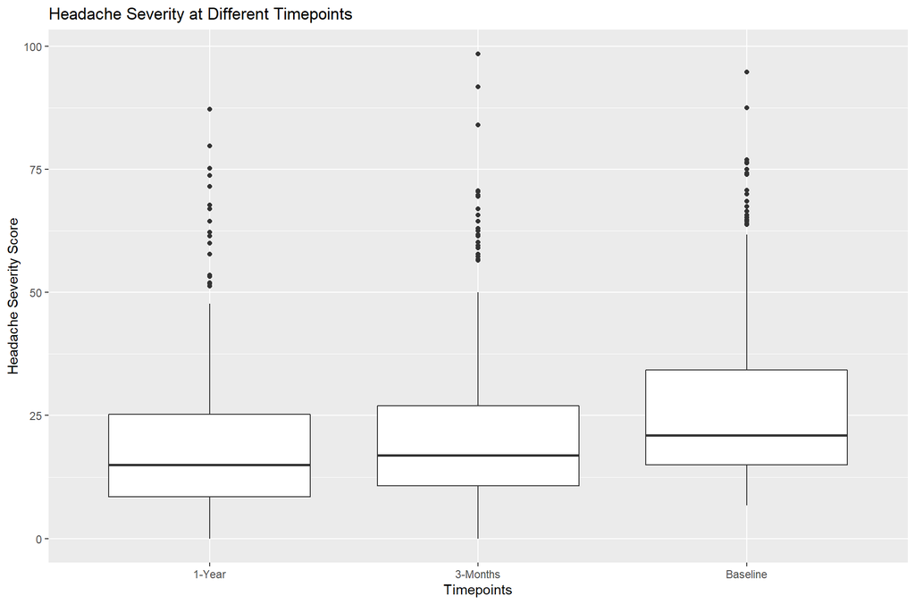

```r
datasimp <- cbind.data.frame(c(rep("Baseline", 401), rep("3-Months", 401), rep("1-Year", 401)), c(data$pk1,
    data$pk2, data$pk5))

f <- ggplot(datasimp, aes(c(rep("Baseline", 401), rep("3-Months", 401), rep("1-Year", 401)), c(data$pk1,
    data$pk2, data$pk5), na.rm = TRUE))
g1 <- ggplot(data, aes(pk1, na.rm = TRUE))
g2 <- ggplot(data, aes(pk2, na.rm = TRUE))
g5 <- ggplot(data, aes(pk5, na.rm = TRUE))

f + geom_boxplot() + xlab("Timepoints") + ylab("Headache Severity Score") + ggtitle("Headache Severity at Different Timepoints")
```

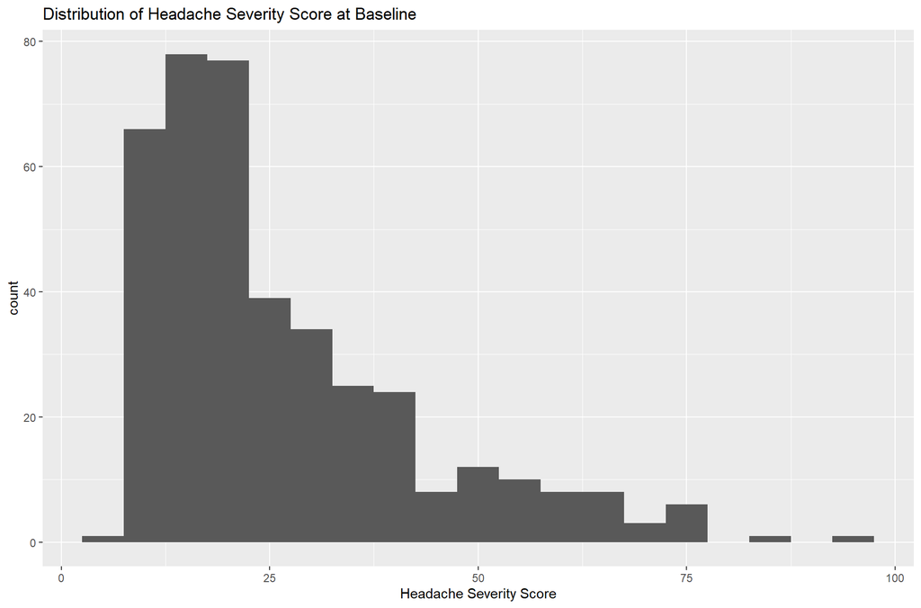

```r
g1 + geom_histogram(binwidth = 5) + xlab("Headache Severity Score") + ggtitle("Distribution of Headache Severity Score at Baseline")
```

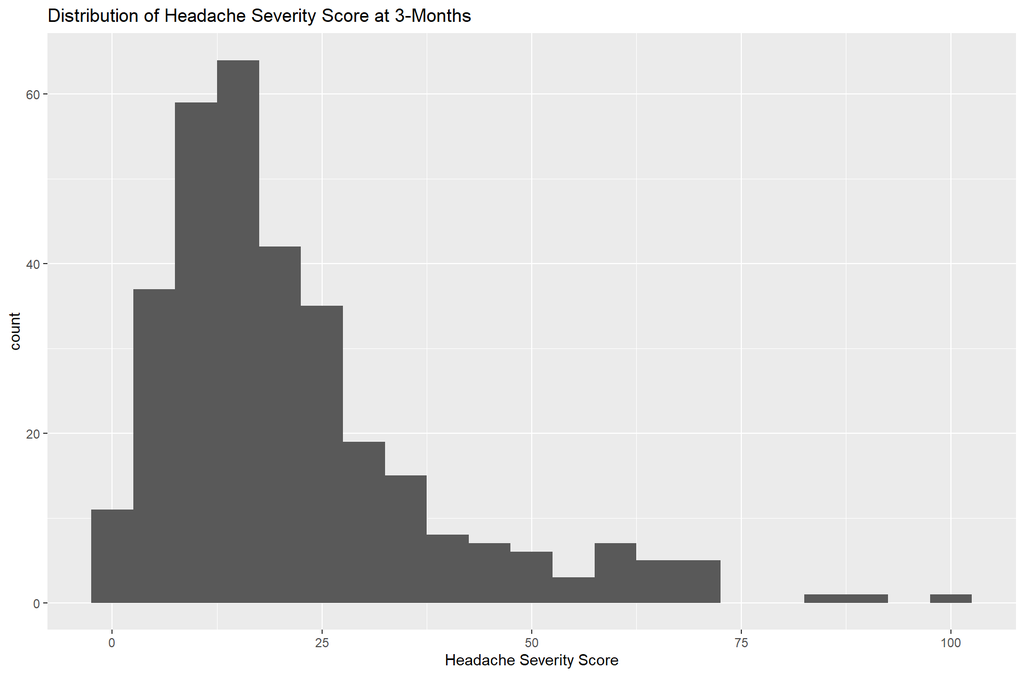

```r
g2 + geom_histogram(binwidth = 5) + xlab("Headache Severity Score") + ggtitle("Distribution of Headache Severity Score at 3-Months")
```

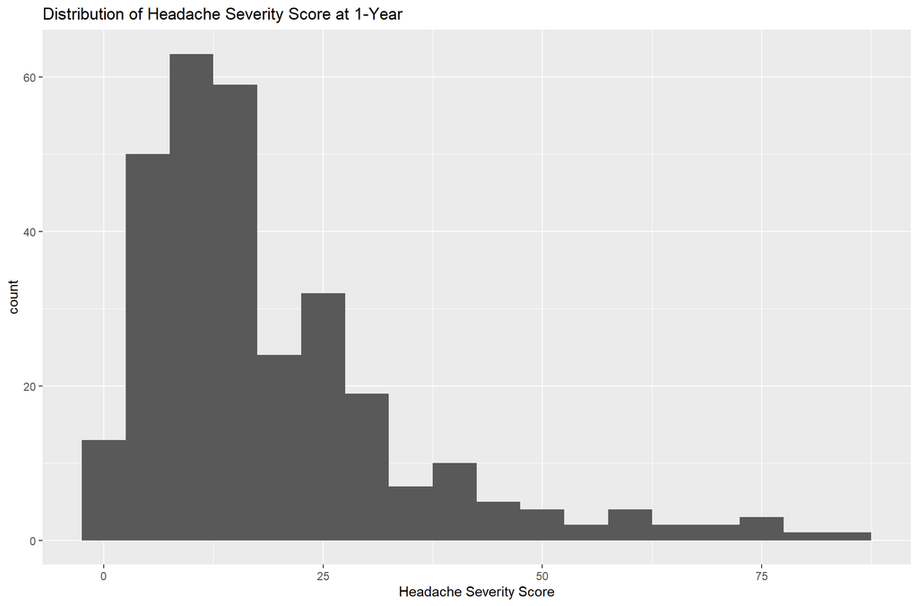

```r
g5 + geom_histogram(binwidth = 5) + xlab("Headache Severity Score") + ggtitle("Distribution of Headache Severity Score at 1-Year")
```

## 1.2 Null and Alternative Hypotheses

The null hypothesis is that there is no significant difference in headache severity score between baseline and 1 year. The alternative hypothesis is that there is a significant difference in headache severity score between baseline and 1 year.

## 1.3 Checking Conditions for a Paired T-Test

We will assume a simple random sample and we know that the sets of observations are dependent as well as that there are more than 30 pairs (individuals measured twice in our case).

## 1.4 Paired T-Test Statistic, P-Value, and Confidence Interval with Interpretation

The two-sided paired t-test statistic is -9.5042, indicating a difference between the average difference and 0. The p-value was 2.2 * 10^16, which indicates a less than .0001% chance of observing the differences we observed if the average difference were truly 0.

The two-sided 95% confidence interval for average difference is (-7.83. -5.14). This is to say that if we repeated the same procedures, the interval given by the data would capture the true population mean difference score 95% of the time and we are therefore 95% confident that the population mean difference score is between -7.83 and -5.14.

```r
t.test(data$change, conf.level = 0.95)
```

```
##
##  One Sample t-test
##
## data:  data$change
## t = -9.5042, df = 300, p-value < 2.2e-16
## alternative hypothesis: true mean is not equal to 0
## 95 percent confidence interval:
##  -7.829550 -5.143429
## sample estimates:
## mean of x
## -6.486489
```

## 1.5 Statistical Decision and Conclusion

Due to a statistically significant p-value (p < .0001), we reject the null hypothesis that the average difference between baseline and 1-year follow-up is 0. We have strong evidence to suggest that the average difference between baseline and 1-year follow-up is significantly less than 0, indicating less severe headaches at 1-year follow-up compared to baseline.

# 2 Difference in Change in Severity Score by Treatment Group

## 2.1 Numerical and Visual Summary

```r
kableExtra::kable(data %>% group_by(group) %>% summarize(pk1_nNA = sum(is.na(pk1)), mean = mean(pk1,
    na.rm = TRUE), SD = sd(pk1, na.rm = TRUE), median = median(pk1, na.rm = TRUE), IQR = quantile(pk1,
    0.75, na.rm = TRUE) - quantile(pk1, 0.25, na.rm = TRUE), min = min(pk1, na.rm = TRUE), max = max(pk1,
    na.rm = TRUE)), digits = 3, "simple", caption = "Numerical Summary of Headache Severity Scores at Baseline by Group")
```

Numerical Summary of Headache Severity Scores at Baseline by Group

| group | pk1_nNA | mean | SD | median | IQR | min | max |
| --- | --- | --- | --- | --- | --- | --- | --- |
| Acupuncture Therapy | 0 | 25.608 | 15.470 | 20.750 | 18.750 | 8.75 | 87.50 |
| Control | 0 | 27.453 | 16.845 | 21.875 | 19.688 | 6.75 | 94.75 |

```r
kableExtra::kable(data %>% group_by(group) %>% summarize(pk2_nNA = sum(is.na(pk2)), mean = mean(pk2,
    na.rm = TRUE), SD = sd(pk2, na.rm = TRUE), median = median(pk2, na.rm = TRUE), IQR = quantile(pk2,
    0.75, na.rm = TRUE) - quantile(pk2, 0.25, na.rm = TRUE), min = min(pk2, na.rm = TRUE), max = max(pk2,
    na.rm = TRUE)), digits = 3, "simple", caption = "Numerical Summary of Headache Severity Scores at 3-month Follow-up by Group")
```

Numerical Summary of Headache Severity Scores at 3-month Follow-up by Group

| group | pk2_nNA | mean | SD | median | IQR | min | max |
| --- | --- | --- | --- | --- | --- | --- | --- |
| Acupuncture Therapy | 32 | 19.052 | 15.651 | 15.00 | 14.75 | 0.5 | 98.50 |
| Control | 43 | 24.477 | 17.593 | 19.25 | 20.25 | 0.0 | 91.75 |

```r
kableExtra::kable(data %>% group_by(group) %>% summarize(pk5_nNA = sum(is.na(pk5)), mean = mean(pk5,
    na.rm = TRUE), SD = sd(pk5, na.rm = TRUE), median = median(pk5, na.rm = TRUE), IQR = quantile(pk5,
    0.75, na.rm = TRUE) - quantile(pk5, 0.25, na.rm = TRUE), min = min(pk5, na.rm = TRUE), max = max(pk5,
    na.rm = TRUE)), digits = 3, "simple", caption = "Numerical Summary of Headache Severity Scores at 1-year Follow-up by Group")
```

Numerical Summary of Headache Severity Scores at 1-year Follow-up by Group

| group | pk5_nNA | mean | SD | median | IQR | min | max |
| --- | --- | --- | --- | --- | --- | --- | --- |
| Acupuncture Therapy | 44 | 16.247 | 13.718 | 12 | 14.250 | 0.00 | 73.733 |
| Control | 56 | 22.343 | 17.011 | 17 | 18.312 | 0.25 | 87.250 |

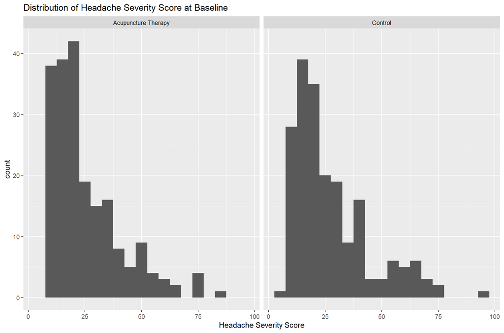

```r
g1 <- ggplot(data, aes(pk1, na.rm = TRUE))
g2 <- ggplot(data, aes(pk2, na.rm = TRUE))
g5 <- ggplot(data, aes(pk5, na.rm = TRUE))

g1 + geom_histogram(binwidth = 5) + xlab("Headache Severity Score") + ggtitle("Distribution of Headache Severity Score at Baseline") +
    facet_wrap(~group)
```

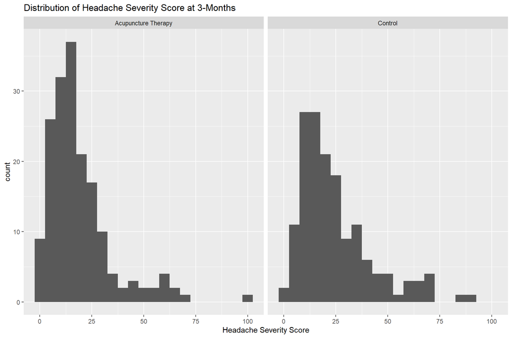

```r
g2 + geom_histogram(binwidth = 5) + xlab("Headache Severity Score") + ggtitle("Distribution of Headache Severity Score at 3-Months") +
    facet_wrap(~group)
```

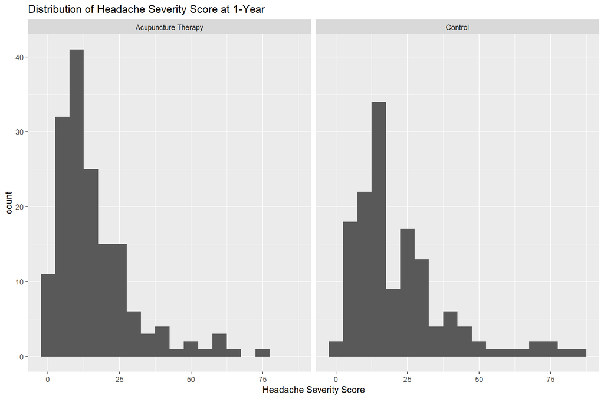

```r
g5 + geom_histogram(binwidth = 5) + xlab("Headache Severity Score") + ggtitle("Distribution of Headache Severity Score at 1-Year") +
    facet_wrap(~group)
```

## Null and Alternative Hypotheses

The Null Hypothesis is that there is no difference in the true population mean difference for those in the acupuncture treatment group compared to those in the no acupuncture control group. The alternative hypothesis is that there is a difference in the true population mean difference for those in the acupuncture treatment group compared to the no acupuncture control group.

Given that we want to use a an independent samples t-test, but are unsure of whether the variances of our samples are equal or not, we will perform an F test for equality of variances. The null hypothesis for this test is that the variances are equal. The alternative hypothesis is that they are not equal.

## 2.2 Conditions for an F test for equality of variances and the F statistic and p-value with interpretation

We will assume the sample is a simple random sample from the two populations of those receiving acupuncture therapy for headaches and those not receiving acupuncture therapy for headaches. We also know the two groups are independent. The outcome data of Headache Severity Score Difference is also roughly normal except for when far away from the mean.

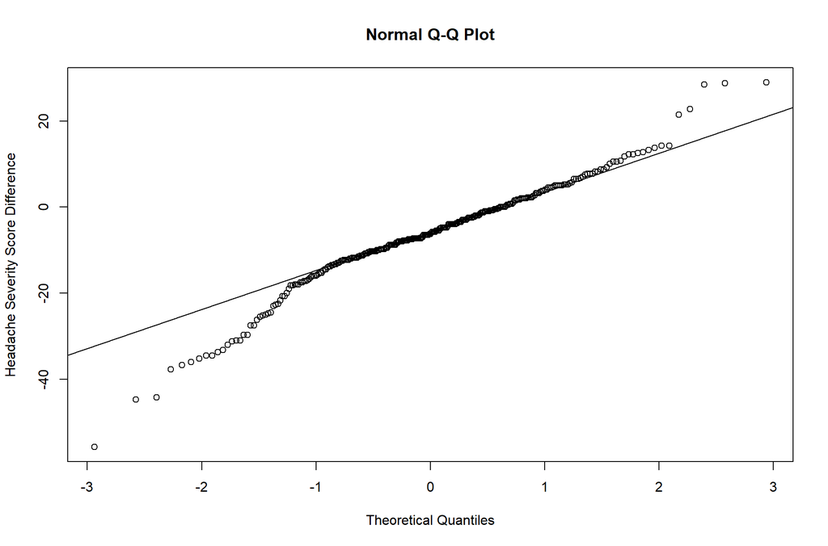

```r
qqnorm(data$change, ylab = "Headache Severity Score Difference")
qqline(data$change)
```

```r
var.test(change ~ group, data = data, alternative = "two.sided", conf.level = 0.95)
```

```
##
##  F test to compare two variances
##
## data:  change by group
## F = 1.4927, num df = 160, denom df = 139, p-value = 0.0157
## alternative hypothesis: true ratio of variances is not equal to 1
## 95 percent confidence interval:
##  1.07909 2.05726
## sample estimates:
## ratio of variances
##           1.492716
```

The F statistic for the F test for equality of variances is 1.4927, indicating the ratio of the variances of the treatment and control groups. The p-value of .0157 indicates a 1.57% chance of observing this variance ratio if the true ratio is equal to 1. Therefore, we reject the null hypothesis that the variances are equal, given a p<.05 is evidence to support the alternative hypothesis that the variances are not equal.

## 2.3 Conditions for Two sample T-Test with Unequal Variances

We assume a simple random sample from the two populations of acupuncture therapy receivers and people who don’t receive acupuncture therapy for headaches. We also assume our 2 groups are independent (no spouses, siblings, etc.). We have more than 30 observations for each group.

## 2.4 Two sample T-statistic, P-Value, and Confidence Interval with Interpretation

The two-sided two sample t statistic for unequal variances that we observe is -2.9729, indicating a difference between the group mean differences in headache severity. The p-value was .003191, which indicates a less than .32% chance of observing the difference we observed if the true difference is 0.

The two-sided 95% confidence interval for the difference between group mean differences is (-6.58. -1.34). This is to say that if we repeated the same procedures, the interval given by the data would capture the true difference between groups 95% of the time and we are therefore 95% confident that the true difference is between -6.58 and -1.34.

```r
t.test(data$change ~ data$group, alternative = "two.sided", conf.level = 0.95)
```

```
##
##  Welch Two Sample t-test
##
## data:  data$change by data$group
## t = -2.9729, df = 297.94, p-value = 0.003191
## alternative hypothesis: true difference in means is not equal to 0
## 95 percent confidence interval:
##  -6.584790 -1.339278
## sample estimates:
## mean in group Acupuncture Therapy             mean in group Control
##                         -8.329296                         -4.367262
```

## 2.5 Statistical Decision and Conclusion

Due to a statistically significant p-value (p < .01), we reject the null hypothesis that there is no difference in differences in headache severity scores between groups. We have strong evidence to suggest that there is a significant difference between groups in the difference in headache severity scores after 1 year.